```r
library(here)
library(tibble)
library(ranger)
library(ggplot2)

source(here("v2","src","evidencegeom.R"))
source(here("v2","src","bcw_train_test_split.R"))

set.seed(42)
```

## Dataset 1: BCW

## TL;DR

This notebook demonstrates the **Evidence Geometry** framework on the **Breast Cancer Wisconsin** dataset.

Instead of relying only on classifier probability, the framework analyzes each case by collecting log likelihood ratios between classes by selecting marginal likelihood distribution families for each feature based on feature type and magnitude of log likelihood.

This log-likelihood ratio space (evidence space) is then analyzed using two geometric risk signals:

- **Distance Contrast (`d_dist`)**: measures which class manifold better explains the case
- **Drift Projection (`proj`)**: measures directional drift toward positive-class structure

### Validation Set Risk Map

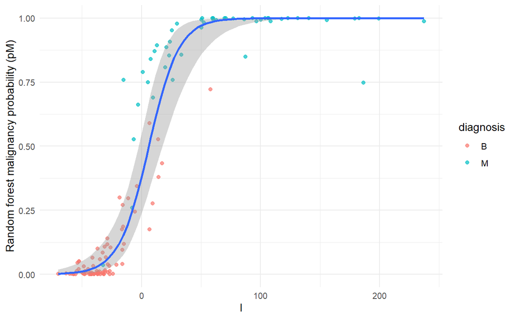

*Random Forest Probability scores vs sum of LLRs closely follow the Logistic regression curve between true class and sum of LLRs, suggesting that sum of LLRs has discriminatory power comparable to Random Forest*

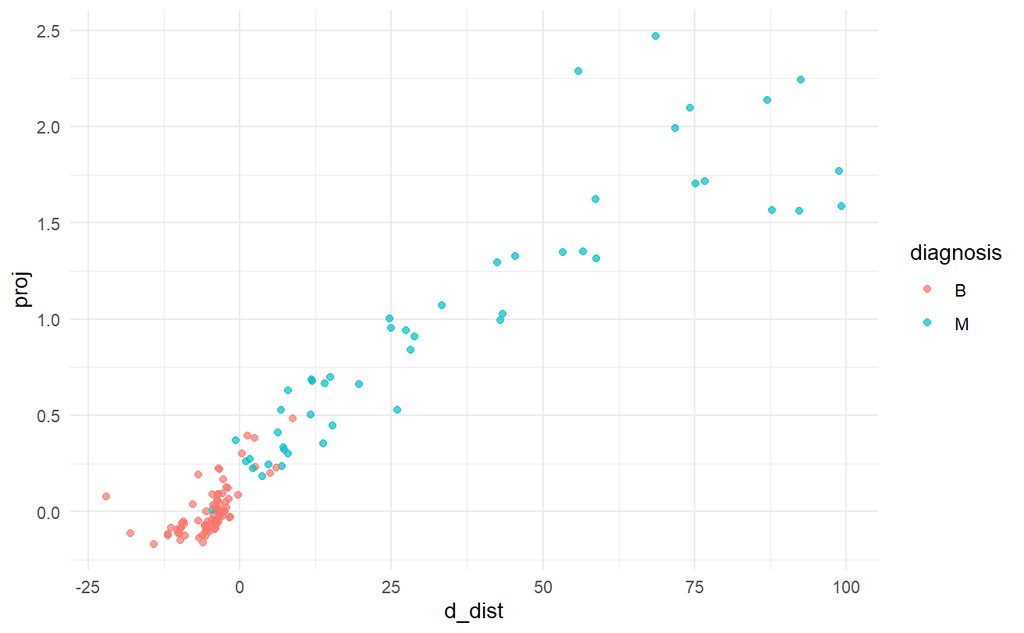

*Validation-set risk map.*

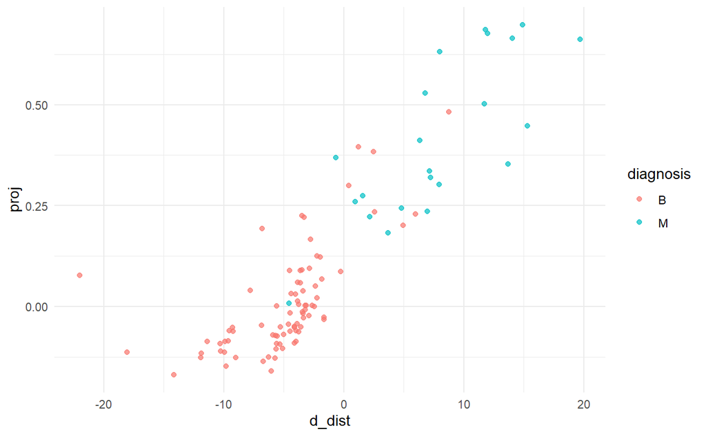

### Main Observation

Within the subset of cases assigned **low probability by the Random Forest (RF) classifier**, the two geometric signals reveal additional structure:

- Sum of LLRs produces decision boundary similar to Random Forest
- Boundary of ambiguity, d_dist = 0, occurs much earlier in the feature space than p = 0.5 classifier ambiguous region.
- Dominant benign cluster is present in the region d_dist < 0, proj < 0.
- Pathological cases are distinctly present among benign points that cross the benign central region of d_dist < 0 and proj < 0.

This suggests that geometric evidence can detect **hidden risk structure earlier than classifier probability alone**.

### Takeaway

`d_dist` and `proj` provide a compact and interpretable view of **how risk accumulates geometrically**, especially in cases where standard discriminative classifiers assign deceptively low probability.

## Full Analysis

### Comment Block : Data prep from BCW raw data

```r
# bcw_import <- read.delim(file=here("src","data","bcw","wdbc.data"), sep=",", header=FALSE)
# names(bcw_import) <- c("id","diagnosis",
#                          "mean_radius","mean_texture","mean_perimeter","mean_area","mean_smoothness","mean_compactness","mean_concavity",
#                          "mean_concave_points","mean_symmetry", "mean_fractal_dimension",
#                          "se_radius","se_texture","se_perimeter","se_area","se_smoothness","se_compactness","se_concavity","se_concave_points",
#                          "se_symmetry", "se_fractal_dimension",
#                          "worst_radius","worst_texture","worst_perimeter","worst_area","worst_smoothness","worst_compactness","worst_concavity",
#                          "worst_concave_points","worst_symmetry", "worst_fractal_dimension")
# bcw_import$id <- as.factor(bcw_import$id)
# bcw_import$diagnosis <- as.factor(bcw_import$diagnosis)
```

```r
# bcw_split_1 <- enriched_split(
#    df = bcw_import,
#    rare_filter = quote(worst_perimeter >= 50 & worst_perimeter <= 105),
#    dev_frac = 0.65,
#    seed = 7
# )
#
# bcw_split_2 <- enriched_split(
#    df = bcw_split_1$dev,
#    rare_filter = quote(worst_perimeter >= 50 & worst_perimeter <= 105),
#    dev_frac = 0.65,
#    seed = 7
# )
#
# bcw_train <- bcw_split_2$dev
# bcw_val  <- bcw_split_2$test
# bcw_test <- bcw_split_1$test
```

```r
# write.csv(bcw_train, here("v2","src","data","bcw","bcw_train.csv"))
# write.csv(bcw_val, here("v2","src","data","bcw","bcw_val.csv"))
# write.csv(bcw_test, here("v2","src","data","bcw","bcw_test.csv"))
```

### Load Train-Val-Test splits

Splits performed ensuring a proportion of known failure modes are present in all three splits

```r
bcw_train <- read.csv(here("v2","src","data","bcw","bcw_train.csv"))
bcw_train <- bcw_train[,-1]
bcw_train$id <- as.factor(bcw_train$id)
bcw_train$diagnosis <- as.factor(bcw_train$diagnosis)

bcw_val <- read.csv(here("v2","src","data","bcw","bcw_val.csv"))
bcw_val <- bcw_val[,-1]
bcw_val$id <- as.factor(bcw_val$id)
bcw_val$diagnosis <- as.factor(bcw_val$diagnosis)

bcw_test <- read.csv(here("v2","src","data","bcw","bcw_test.csv"))
bcw_test <- bcw_test[,-1]
bcw_test$id <- as.factor(bcw_test$id)
bcw_test$diagnosis <- as.factor(bcw_test$diagnosis)
```

#### Class overlap and hidden failures

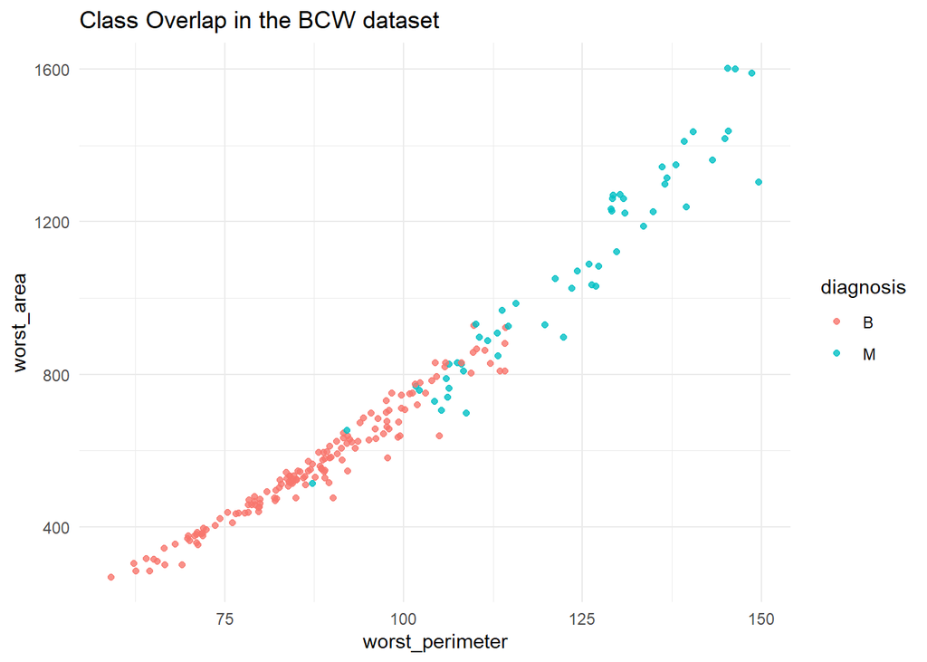

```r
ggplot(bcw_train%>%filter(worst_perimeter >= 50 & worst_perimeter <= 150)) +
  geom_point(aes(x=worst_perimeter, y=worst_area, color=diagnosis), alpha=0.8) +
  labs(title="Class Overlap in the BCW dataset") +
  theme_minimal()
```

```r
nrow(bcw_train%>%filter(worst_perimeter >= 50 & worst_perimeter <= 105))
```

```
## [1] 141
```

### Class Ratio to input for generating Evidence Space

```r
alpha <- (nrow(bcw_train[bcw_train$diagnosis=="M", ])/nrow(bcw_train))
```

## Evidence Space Transformation

**risk_spec** : Object to store function argument values for evidence space generation

**fit** : Learn feature-wise marginal likelihoods, and geometries and eigenmodes of class manifolds in evidence space

**loglik_matrices** : Compute marginal positive-class and negative-class evidences, and marginal relative evidence for input data using fitted evidence generator

**score_risk** : Compute total feature-wise evidence, distance constrast, drift projection, and eigenmode energies

### Generate Evidence Space

```r
bcw_spec <- risk_spec(
   y_col="diagnosis", positive="M",
   features = setdiff(names(bcw_train), c("diagnosis", "id")),
   alpha = alpha,
   laplace = 1, ridge = 1e-6, winsor_p=0.01,
   weights=FALSE,
   weight_method = "mutual_info",
   numeric_candidates = c("gaussian", "lognormal", "gamma"),
   numeric_val_frac = 0.2,
   numeric_min_n = 25,
   llr_cap_quantile = 0.01,
   mi_nbins = 10
 )

bcw_obj <- fit(bcw_train%>%select(-id), bcw_spec, k_eigen=2, k_energy=2, energy_ref="both")
```

```r
head(print_feature_likelihoods(bcw_obj), 5)
```

```
##          feature    class feature_type likelihood_family
## 1    mean_radius positive      numeric             gamma
## 2    mean_radius negative      numeric             gamma
## 3   mean_texture positive      numeric         lognormal
## 4   mean_texture negative      numeric         lognormal
## 5 mean_perimeter positive      numeric         lognormal
##                     parameters
## 1   shape=31.2318, rate=1.7828
## 2   shape=61.2763, rate=5.0253
## 3 meanlog=3.0542, sdlog=0.1419
## 4 meanlog=2.8619, sdlog=0.2097
## 5 meanlog=4.7341, sdlog=0.1847
```

```r
bcw_Lval <- loglik_matrices(bcw_val%>%select(-id), bcw_obj$fit, alpha=bcw_spec$alpha)
# val/test scoring
bcw_scores_val <- bind_cols(id=bcw_val$id,
                            diagnosis=bcw_val$diagnosis,
                            score_risk(bcw_Lval$l_pos, bcw_Lval$l_neg,  bcw_obj$fit$weights, bcw_obj$geom,
                                       bcw_spec$alpha, bcw_spec$eps))
```

```r
bcw_Lval_w <- apply_llr_weights(bcw_Lval$L, bcw_obj$fit$weights)
```

### Learn baseline Random Forest and predict

```r
bcw_rf_train_1 <- ranger(formula = diagnosis ~ ., data=bcw_train%>%select(-id),
                         mtry=8, min.node.size=5, num.trees=500, probability = TRUE,
                         keep.inbag = TRUE)
```

```r
bcw_scores_val <- bind_cols(bcw_scores_val,
                            pM = predict(bcw_rf_train_1, bcw_val%>%select(-id, -diagnosis))$predictions[,"M"])
```

### Feature Importance using ratio of feature-wise evidences

```r
feature_importance(df=bcw_train%>%select(-id), y_col="diagnosis", fit = bcw_obj$fit, method = "mutual_info", top_n = 15)
```

```
##                 feature     weight abs_weight
## 1       worst_perimeter 0.06802118 0.06802118
## 2            worst_area 0.06720117 0.06720117
## 3          worst_radius 0.06703131 0.06703131
## 4   mean_concave_points 0.06541001 0.06541001
## 5  worst_concave_points 0.06488235 0.06488235
## 6             mean_area 0.06011327 0.06011327
## 7           mean_radius 0.05935002 0.05935002
## 8        mean_perimeter 0.05923074 0.05923074
## 9        mean_concavity 0.05640648 0.05640648
## 10      worst_concavity 0.05002912 0.05002912
## 11              se_area 0.04956444 0.04956444
## 12            se_radius 0.03496687 0.03496687
## 13    worst_compactness 0.03488927 0.03488927
## 14     mean_compactness 0.03328922 0.03328922
## 15         se_perimeter 0.03231747 0.03231747
```

### Sample from evidence output

**l_pos** : Sum of marginal positive evidence  
**l_neg** : Sum of marginal negative evidence  
**l** : Sum of marginal evidence (difference of positive and negative evidence)  
**proj** : Projection of benign-relative z scores of evidences on mean deviation class separation direction learned from training  
**d_dist** : Difference of Mahalanobis Distances of evidence vector from negative-class evidence manifold and positive-class evidence manifold  
**E_pos** : Total energy (sum of squares of projections over k principal components of positive-class) of evidence vector  
**pM** : Random Forest probability score for positive-class

```r
head(bcw_scores_val, 5)
```

```
##       id diagnosis      l_pos      l_neg          l          t         proj
## 1 913512         B  -7.181215  25.174531 -32.355746  17.993315 -0.014474594
## 2 863031         B  -1.687254  19.441711 -21.128966  17.754457  0.002029465
## 3 855138         M   7.536457  -2.010215   9.546673   5.526242  0.241179508
## 4 883270         B  -8.495305   2.749076 -11.244380  -5.746229  0.166289857
## 5 921362         B -62.346930 -31.269338 -31.077592 -93.616268 -0.068812180
##      d_dist    l_norm      E_pos       E_neg          dE     eig_1     eig_2
## 1 -4.640003  8.647529  0.3514493   0.9006716  -0.5492223  7.842260 0.5472624
## 2 -2.529992  8.003247  5.5361752   6.5353216  -0.9991463  6.762143 2.8967998
## 3  6.814686 10.884689 78.3435176 152.1444580 -73.8009404 -1.541281 5.3848165
## 4 -2.850673  5.250365 26.9890565  35.6939991  -8.7049426  1.924869 0.2263808
## 5 -8.426509 13.472078 24.8759126  17.9959150   6.8799976  9.493974 5.1267741
##           pM
## 1 0.00740000
## 2 0.03666667
## 3 0.68913333
## 4 0.29660000
## 5 0.10830000
```

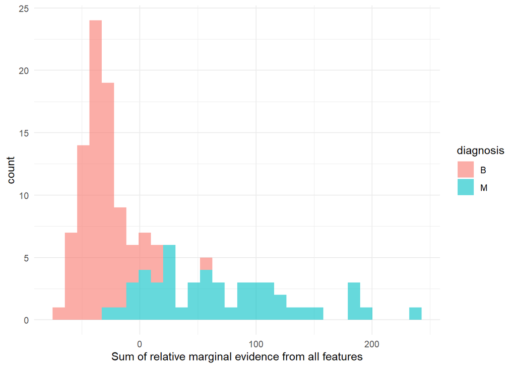

```r
ggplot(bcw_scores_val) +
  geom_histogram(aes(x=l, fill=diagnosis), alpha=0.6) +
  xlab("Sum of relative marginal evidence from all features") +
  theme_minimal()
```

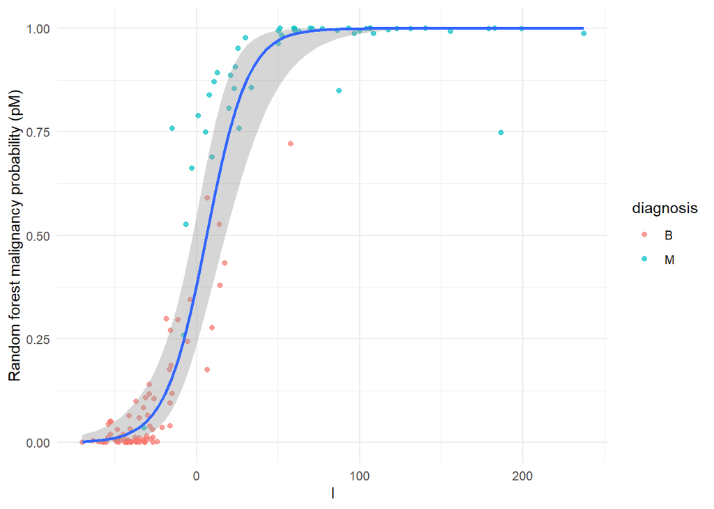

```r
ggplot(bcw_scores_val) +
  geom_point(aes(x=l, y=pM, color=diagnosis), alpha=0.7) +
  stat_smooth(aes(x=l, y=as.numeric(diagnosis)-1), method = "glm", # Specify Generalized Linear Model
              method.args = list(family = "binomial"), # Specify logistic regression
              se = TRUE) +
  ylab("Random forest malignancy probability (pM)") +
  theme_minimal()
```

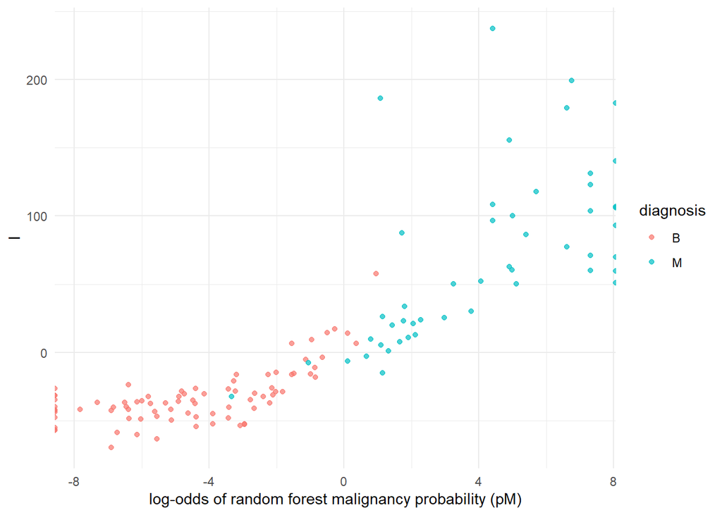

```r
ggplot(bcw_scores_val) +
  geom_point(aes(x=qlogis(pM), y=l, color=diagnosis), alpha=0.7) +
  xlab("log-odds of random forest malignancy probability (pM)") +
  theme_minimal()
```

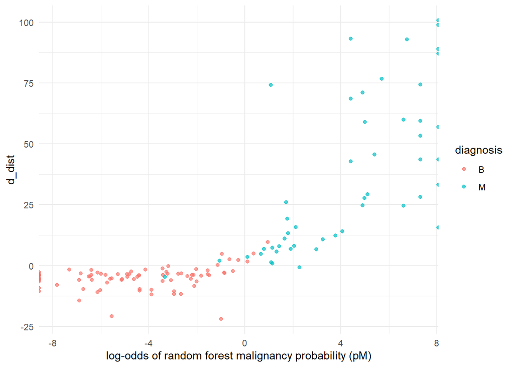

```r
ggplot(bcw_scores_val) +
  geom_point(aes(x=qlogis(pM), y=d_dist, color=diagnosis), alpha=0.7) +
  xlab("log-odds of random forest malignancy probability (pM)") +
  theme_minimal()
```

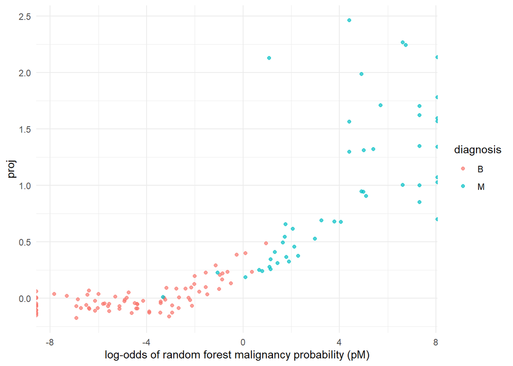

```r
ggplot(bcw_scores_val) +
  geom_point(aes(x=qlogis(pM), y=proj, color=diagnosis), alpha=0.7) +
  xlab("log-odds of random forest malignancy probability (pM)") +
  theme_minimal()
```

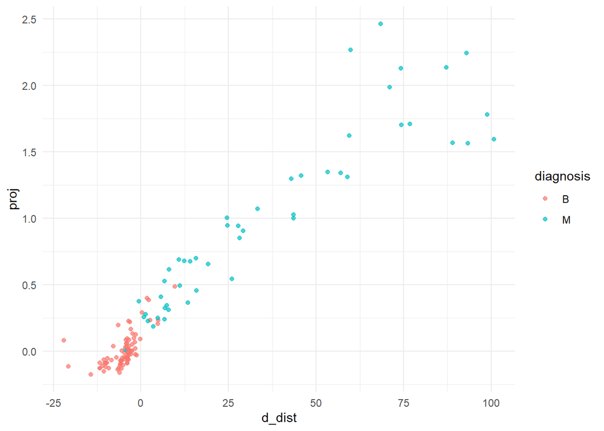

```r
ggplot(bcw_scores_val) +
  geom_point(aes(x=d_dist, y=proj, color=diagnosis), alpha=0.7) +
  theme_minimal()
```

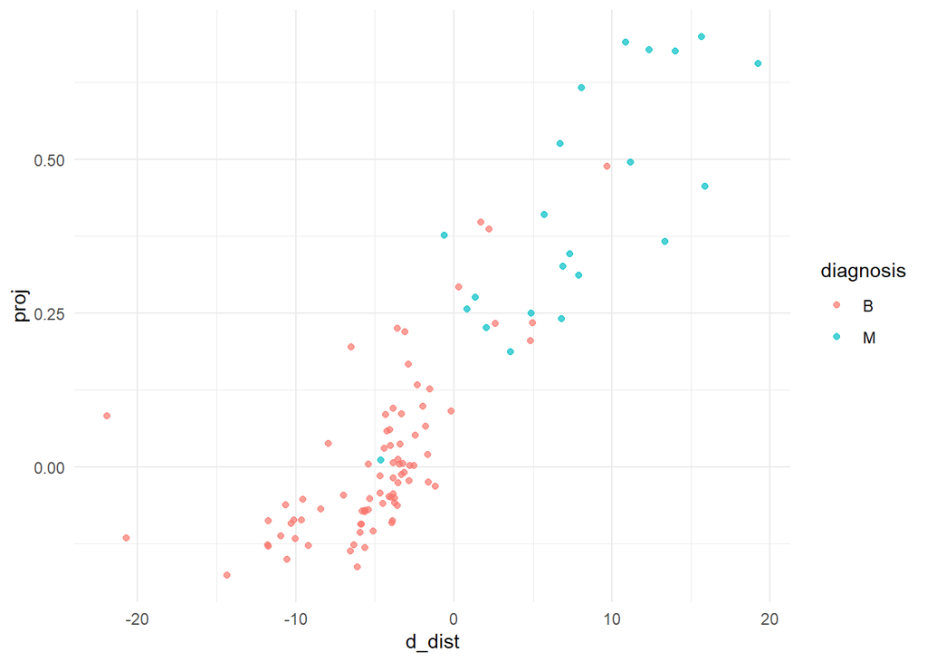

```r
ggplot(bcw_scores_val%>%filter(d_dist < 20)) +
  geom_point(aes(x=d_dist, y=proj, color=diagnosis), alpha=0.7) +
  theme_minimal()
```

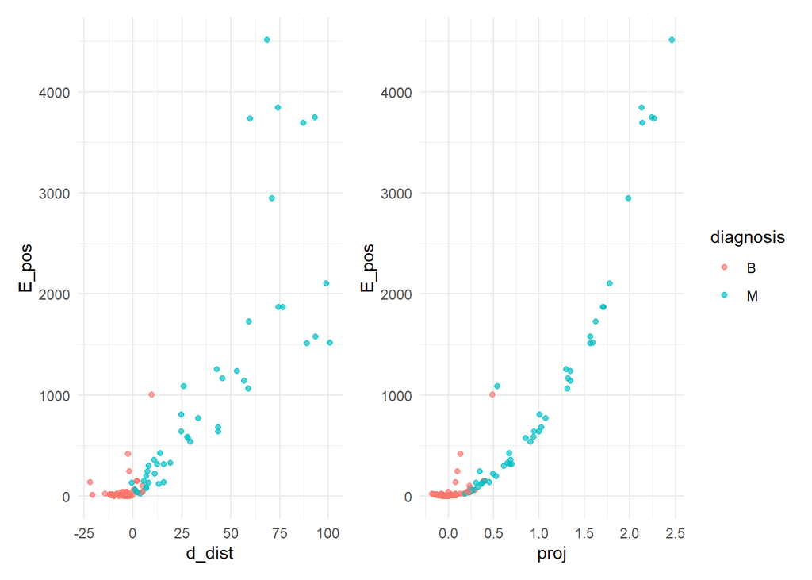

```r
patchwork::wrap_plots(
ggplot(bcw_scores_val) +
  geom_point(aes(x=d_dist, y=E_pos, color=diagnosis), alpha=0.7) +
  theme_minimal(),

ggplot(bcw_scores_val) +
  geom_point(aes(x=proj, y=E_pos, color=diagnosis), alpha=0.7) +
  theme_minimal()
) + patchwork::plot_layout(guides="collect")
```

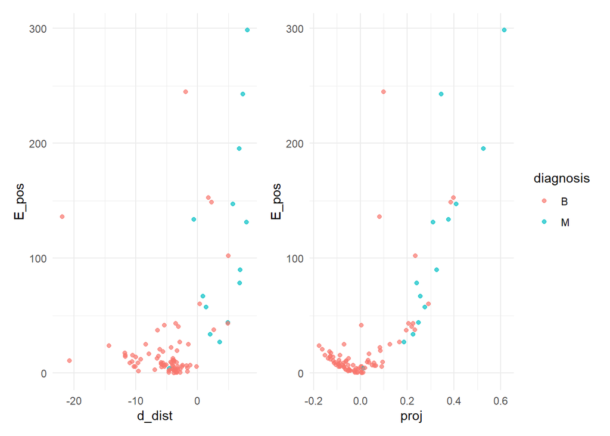

```r
patchwork::wrap_plots(

ggplot(bcw_scores_val%>%filter(d_dist < 10, E_pos < 400)) +
  geom_point(aes(x=d_dist, y=E_pos, color=diagnosis), alpha=0.7) +
  theme_minimal(),

ggplot(bcw_scores_val%>%filter(d_dist < 10, E_pos < 400)) +
  geom_point(aes(x=proj, y=E_pos, color=diagnosis), alpha=0.7) +
  theme_minimal()
) + patchwork::plot_layout(guides="collect")
```

```r
bcw_val_L <- bind_cols(diagnosis=bcw_val$diagnosis,
           bcw_Lval$L)
```

### Case-wise Feature Importance on validation set using unweighted relative evidence

#### Malignant cases

```r
#apply(bcw_val_L, 1, function (x) {max(abs(x)) / sum(abs(x))})
bcw_val_M_dom_l <- apply(bcw_val_L%>%filter(diagnosis=="M")%>%select(-diagnosis), 1,
               function (x) {list(dom_l = sum(head(sort(abs(x), decreasing=TRUE),3)) / sum(abs(x)),
                                  dom_l_names = names(head(sort(abs(x), decreasing=TRUE),3)))})

bcw_val_M_dom_l <- bcw_val_M_dom_l[order(sapply(bcw_val_M_dom_l, function(x) x$dom_l), decreasing=TRUE)]

head(bcw_val_M_dom_l, 3)
```

```
## [[1]]
## [[1]]$dom_l
## [1] 0.4986962
##
## [[1]]$dom_l_names
## [1] "worst_radius"    "worst_perimeter" "worst_area"
##
##
## [[2]]
## [[2]]$dom_l
## [1] 0.4476173
##
## [[2]]$dom_l_names
## [1] "worst_concavity"         "mean_concavity"
## [3] "worst_fractal_dimension"
##
##
## [[3]]
## [[3]]$dom_l
## [1] 0.4400803
##
## [[3]]$dom_l_names
## [1] "worst_radius"    "worst_perimeter" "worst_area"
```

#### Benign cases

```r
bcw_val_B_dom_l <- sort(apply(bcw_val_L%>%filter(diagnosis=="B")%>%select(-diagnosis), 1,
               function (x) {sum(head(sort(abs(x), decreasing=TRUE),3)) / sum(abs(x))}), decreasing=TRUE)

head(bcw_val_B_dom_l, 3)
```

```
## [1] 0.5925254 0.4787052 0.4625822
```

```r
tail(bcw_val_B_dom_l, 3)
```

```
## [1] 0.2135967 0.2131890 0.2097654
```

### Eigenmode Analysis (PCA) on validation set

### Eigenmodes of malignant subset

```r
bcw_Lval_w_M <- bcw_Lval_w[bcw_val$diagnosis == "M", , drop = FALSE]
bcw_Lval_w_Sigma_M <- cov(bcw_Lval_w_M)
bcw_Lval_w_Sigma_M <- bcw_Lval_w_Sigma_M + diag(1e-6, ncol(bcw_Lval_w_Sigma_M))
bcw_Lval_w_eig_M <- eigen(bcw_Lval_w_Sigma_M, symmetric = TRUE)

bcw_Lval_w_eigvals_M  <- bcw_Lval_w_eig_M$values
bcw_Lval_w_eigvecs_M  <- bcw_Lval_w_eig_M$vectors

bcw_Lval_w_coords_M <- bcw_Lval_w_M %*% bcw_Lval_w_eigvecs_M[, 1:2]
```

#### Variance Explained

```r
bcw_Lval_w_eigvals_M[1:2] / sum(bcw_Lval_w_eigvals_M[1:2])
```

```
## [1] 0.8062571 0.1937429
```

#### Top 5 feature loadings

```r
decompose_eigenmode(bcw_Lval_w_eigvecs_M, k=1, feature_names = bcw_obj$fit$features, top_n=5)
```

```
## # A tibble: 5 × 3
##   feature             loading abs_loading
##   <chr>                 <dbl>       <dbl>
## 1 mean_concave_points  -0.482       0.482
## 2 worst_radius         -0.454       0.454
## 3 mean_concavity       -0.382       0.382
## 4 worst_perimeter      -0.314       0.314
## 5 worst_area           -0.227       0.227
```

```r
decompose_eigenmode(bcw_Lval_w_eigvecs_M, k=2, feature_names = bcw_obj$fit$features, top_n=5)
```

```
## # A tibble: 5 × 3
##   feature              loading abs_loading
##   <chr>                  <dbl>       <dbl>
## 1 mean_concavity         0.408       0.408
## 2 worst_concavity        0.371       0.371
## 3 mean_compactness       0.362       0.362
## 4 worst_radius          -0.356       0.356
## 5 worst_concave_points   0.230       0.230
```

#### Eigenmode Plot

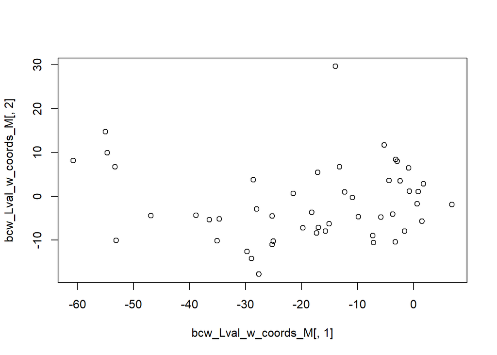

```r
plot(bcw_Lval_w_coords_M[,1], bcw_Lval_w_coords_M[,2])
```

### Eigenmodes of Benign subset

```r
bcw_Lval_w_B <- bcw_Lval_w[bcw_val$diagnosis == "B", , drop = FALSE]
bcw_Lval_w_Sigma_B <- cov(bcw_Lval_w_B)
bcw_Lval_w_Sigma_B <- bcw_Lval_w_Sigma_B + diag(1e-6, ncol(bcw_Lval_w_Sigma_B))
bcw_Lval_w_eig_B <- eigen(bcw_Lval_w_Sigma_B, symmetric = TRUE)

bcw_Lval_w_eigvals_B  <- bcw_Lval_w_eig_B$values
bcw_Lval_w_eigvecs_B  <- bcw_Lval_w_eig_B$vectors

bcw_Lval_w_coords_B <- bcw_Lval_w_B %*% bcw_Lval_w_eigvecs_B[, 1:2]
```

#### Variance Explained

```r
bcw_Lval_w_eigvals_B[1:2] / sum(bcw_Lval_w_eigvals_B[1:2])
```

```
## [1] 0.7269915 0.2730085
```

#### Top 5 feature loadings

```r
decompose_eigenmode(bcw_Lval_w_eigvecs_B, k=1, feature_names = bcw_obj$fit$features, top_n=5)
```

```
## # A tibble: 5 × 3
##   feature              loading abs_loading
##   <chr>                  <dbl>       <dbl>
## 1 mean_concavity         0.686       0.686
## 2 mean_compactness       0.355       0.355
## 3 worst_concavity        0.319       0.319
## 4 worst_concave_points   0.264       0.264
## 5 mean_concave_points    0.255       0.255
```

```r
decompose_eigenmode(bcw_Lval_w_eigvecs_B, k=2, feature_names = bcw_obj$fit$features, top_n=5)
```

```
## # A tibble: 5 × 3
##   feature         loading abs_loading
##   <chr>             <dbl>       <dbl>
## 1 worst_area        0.420       0.420
## 2 mean_perimeter    0.400       0.400
## 3 mean_area         0.391       0.391
## 4 worst_perimeter   0.327       0.327
## 5 mean_radius       0.315       0.315
```

#### Eigenmode Plot

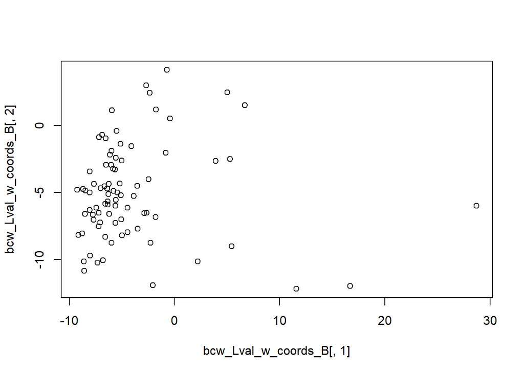

```r
plot(bcw_Lval_w_coords_B[,1], bcw_Lval_w_coords_B[,2])
```

```r
acos((t(bcw_Lval_w_eigvecs_B[,1]) %*% bcw_Lval_w_eigvecs_M[,1]) / (sqrt(t(bcw_Lval_w_eigvecs_B[,1]) %*% bcw_Lval_w_eigvecs_B[,1]) * sqrt(t(bcw_Lval_w_eigvecs_M[,1]) %*% bcw_Lval_w_eigvecs_M[,1]))) * 180 / pi
```

```
##          [,1]
## [1,] 131.5815
```

### Fitting Evidence Model and Random Forest on train+val set

```r
bcw_obj_2 <- fit(bind_rows(bcw_train%>%select(-id),
                           bcw_val%>%select(-id)), bcw_spec, k_eigen=2, k_energy=2, energy_ref="both")

bcw_Lval_test <- loglik_matrices(bcw_test%>%select(-id), bcw_obj_2$fit, alpha=bcw_spec$alpha)
# val/test scoring
bcw_scores_test <- bind_cols(id=bcw_test$id,
                            diagnosis=bcw_test$diagnosis,

                            score_risk(bcw_Lval_test$l_pos, bcw_Lval_test$l_neg,  bcw_obj_2$fit$weights, bcw_obj_2$geom,
                                       bcw_spec$alpha, bcw_spec$eps))
```

```r
head(print_feature_likelihoods(bcw_obj_2), 5)
```

```
##          feature    class feature_type likelihood_family
## 1    mean_radius positive      numeric             gamma
## 2    mean_radius negative      numeric             gamma
## 3   mean_texture positive      numeric         lognormal
## 4   mean_texture negative      numeric         lognormal
## 5 mean_perimeter positive      numeric          gaussian
##                     parameters
## 1   shape=31.6265, rate=1.8164
## 2   shape=54.4581, rate=4.4767
## 3 meanlog=3.0583, sdlog=0.1598
## 4 meanlog=2.8716, sdlog=0.2073
## 5    mean=114.8236, sd=21.1460
```

```r
feature_importance(df=bind_rows(bcw_train%>%select(-id),
                           bcw_val%>%select(-id)), y_col="diagnosis", fit = bcw_obj_2$fit, method = "mutual_info", top_n = 15)
```

```
##                 feature     weight abs_weight
## 1          worst_radius 0.07318007 0.07318007
## 2            worst_area 0.07300859 0.07300859
## 3       worst_perimeter 0.07184495 0.07184495
## 4  worst_concave_points 0.06896854 0.06896854
## 5   mean_concave_points 0.06589216 0.06589216
## 6        mean_perimeter 0.06134988 0.06134988
## 7           mean_radius 0.05846728 0.05846728
## 8             mean_area 0.05846728 0.05846728
## 9        mean_concavity 0.05498769 0.05498769
## 10              se_area 0.05403280 0.05403280
## 11      worst_concavity 0.04891966 0.04891966
## 12            se_radius 0.03747952 0.03747952
## 13    worst_compactness 0.03286711 0.03286711
## 14         se_perimeter 0.03233489 0.03233489
## 15     mean_compactness 0.02980909 0.02980909
```

```r
bcw_rf_train_2 <- ranger(formula = diagnosis ~ ., data=bind_rows(bcw_train%>%select(-id), bcw_val%>%select(-id)),
                         mtry=8, min.node.size=5, num.trees=500, probability = TRUE,
                         keep.inbag = TRUE)
```

## Test Set Performace

```r
bcw_scores_test <- bind_cols(bcw_scores_test,
                            pM = predict(bcw_rf_train_2, bcw_test%>%select(-id))$predictions[,"M"])
```

### Triage Rule

**If** $p \geq 0.65$ $\rightarrow$ **Malignant**  
**Else If** $p > 0.45$ $\rightarrow$ **Review**  
**Else**  
**If** $proj > 0$ & $d\_dist \geq 0$ $\rightarrow$ **Review**  
**Else** $\rightarrow$ **Benign**

```r
apply_bcw_triage <- function(df, p_hi = 0.65, p_review = 0.45, tau_d = 0, tau_p = 0) {
  df %>%
    mutate(
      action = case_when(
        pM >= p_hi ~ "Malignant",
        pM > p_review ~ "Review",
        (pM <= p_review) & (proj > tau_p) & (d_dist >= tau_d) ~ "Review",
        # (pM <= p_review) & (d_dist >= tau_d) ~ "Review",
        TRUE ~ "Benign"
      )
    )
}

triage_table <- function(df, truth_col = "diagnosis", action_col = "action") {
  tab <- table(df[[action_col]], df[[truth_col]])
  as.data.frame.matrix(tab) %>%
    tibble::rownames_to_column(action_col)
}
```

### Triage Results

```r
bcw_test_triaged <- bcw_scores_test %>%
  apply_bcw_triage(p_hi = 0.65, p_review = 0.45, tau_d = 0, tau_p = 0)

triage_table(bcw_test_triaged, truth_col = "diagnosis", action_col = "action")
```

```
##      action   B  M
## 1    Benign 113  1
## 2 Malignant   4 70
## 3    Review   9  4
```

```r
bcw_metrics <- function(df, truth_col = "diagnosis") {
  truth <- df[[truth_col]]
  stopifnot(all(levels(truth) %in% c("B","M")))

  benign_path <- df %>% filter(action == "Benign")
  review_path <- df %>% filter(action == "Review")
  mal_path <- df %>% filter(action == "Malignant")

  tibble(
    auto_benign_fn_rate = mean(benign_path[[truth_col]] == "M"),
    fn_capture_rate = 1 - mean(df[[truth_col]] == "M" & df$action == "Benign"),
    overall_review_rate = mean(df$action == "Review"),
    benign_region_review_rate = mean(df$pM <= 0.45 & df$action == "Review") / mean(df$pM <= 0.45),
    malignant_region_fp_override_rate = mean(df$pM >= 0.65 & df[[truth_col]] == "B") / mean(df$pM >= 0.65) # optional
  )
}

bcw_metrics(bcw_test_triaged)
```

```
## # A tibble: 1 × 5
##   auto_benign_fn_rate fn_capture_rate overall_review_rate benign_region_review…¹
##                 <dbl>           <dbl>               <dbl>                  <dbl>
## 1             0.00877           0.995              0.0647                 0.0732
## # ℹ abbreviated name: ¹benign_region_review_rate
## # ℹ 1 more variable: malignant_region_fp_override_rate <dbl>
```